# Phys434_HW1

```python
import numpy as np
import matplotlib
import matplotlib.pyplot as plt
import scipy
from scipy import stats

#this sets the size of the plot to something useful
plt.rcParams["figure.figsize"] = (15,10)
```

### Example

```python
d = stats.norm.rvs(loc = 5.0, scale = .01, size = 1000000)
```

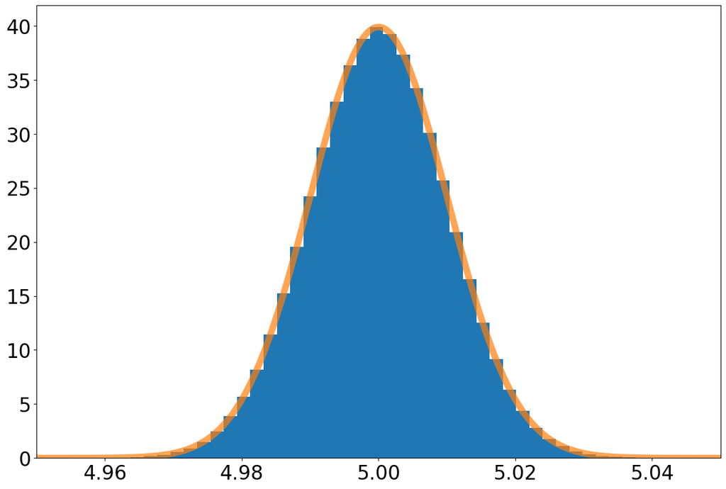

```python
fig, ax = plt.subplots(1, 1)
ax.hist(d,50, density=True)
plt.tick_params(labelsize = 24)
plt.xlim([4.95,5.05])
x = np.linspace(4.95,5.05,1000)
ax.plot(x,stats.norm.pdf(x,loc = 5., scale = 0.01),linewidth = 8,alpha = 0.7)
plt.show()
```

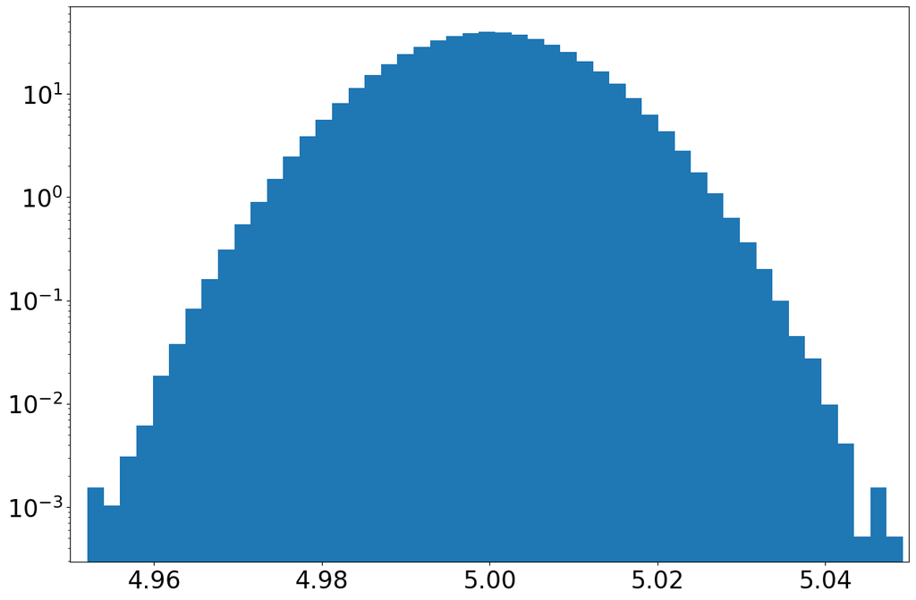

```python
ax = plt.hist(d,50, density=True)
plt.yscale('log')
plt.tick_params(labelsize = 24)
plt.xlim([4.95,5.05])
plt.show()
```

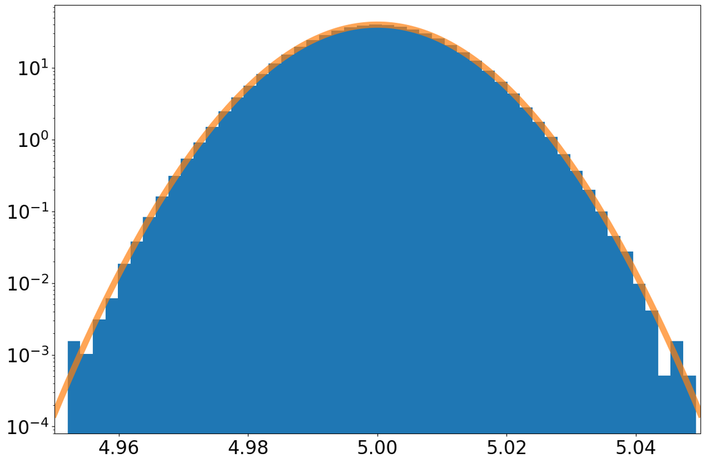

```python
fig, ax = plt.subplots(1, 1)
ax.hist(d,50, density=True)
plt.yscale('log')
plt.tick_params(labelsize = 24)
plt.xlim([4.95,5.05])
x = np.linspace(4.95,5.05,1000)
ax.plot(x,stats.norm.pdf(x,loc = 5., scale = 0.01),linewidth = 8,alpha = 0.7)
plt.show()
```

It is often very useful to put in latex equations such as:

$$ f(x) = \frac{1}{\sqrt{2\pi\sigma^2}}e^\frac{-(x-\mu)^2}{2\sigma^2} $$

This is done using $$ latex equation $$

### Homework

Pick a different central value and width for your Gaussian distribution. Show the plots generated as in this homework, describing in your own words and math the steps along the way using code, plots, markdown, and equations.

```python
my_d = stats.norm.rvs(loc = -10.0, scale = .05, size = 1000000)
```

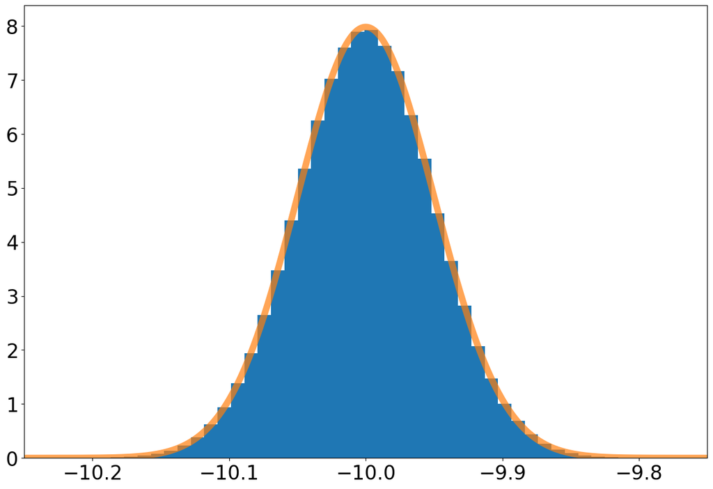

```python
fig, ax = plt.subplots(1, 1)
ax.hist(my_d, 50, density = True)
plt.tick_params(labelsize = 24)
plt.xlim([-10.25, -9.75])
x = np.linspace(-10.25, -9.75, 1000)
ax.plot(x, stats.norm.pdf(x, loc = -10.0, scale = 0.05), linewidth = 8, alpha = 0.7)
plt.show()
```

- fig, ax = plt.subplots(1, 1)
  - Creates a figure with one subplot on it (1 row, 1 column)
  - fig, ax = plt.subplots(# of subplots in row, # of subplots in column)
- ax.hist(my_d, 50, density=True)
  - Creates a probability density histogram plotting my_d (my gaussian distribution) into 50 bins
  - ax.hist(x = my data, bins = # of bins, density=True)
    - Density = True returns probability density where density = (# of bins) / ((# of total counts) * (bin width)) so that the area under the histogram integrates to 1
- plt.tick_params(labelsize = 24)
  - Changes the fontsize of the labels for the tick marks to size 24
  - plt.tick_params(labelsize = size)
- plt.xlim([-10.25,-9.75])
  - Changes the lower limit of x-axis to -10.25 and the upper limit of x-axis to -9.75
  - xlim([left = lower limit to x-axis, right = upper limit to x-axis])
- x = np.linspace(-10.25 , -9.75, 1000)
  - Defines x as an array of 1000 numbers evenly spaced between -10.25 and -9.75
  - numpy.linspace(start = start value, stop = stop value, num = number of evenly spaced samples between [start, stop])
- ax.plot(x, stats.norm.pdf(x, loc = -10.0, scale = 0.05), linewidth = 8, alpha = 0.7)
  - Plots curve from defined x and y from stats.norm.pdf with a linewidth of 8 and an opacity of 0.7
  - ax.plot(x, y, linewidth = width of line plotted, alpha = opacity of line plotted)
  - stats.norm.pdf(x, loc = -10.0, scale = 0.05)
    - Plots a probability density function from the defined x with a central value of -10 and standard deviation of 0.05 (same as my_d)
    - stats.norm.pdf(x, loc = central value or mean, scale = standard deviation)
- plt.show()
  - Displays figure

Plots a pdf histogram of the random sample against the predicted pdf of the normal distribution

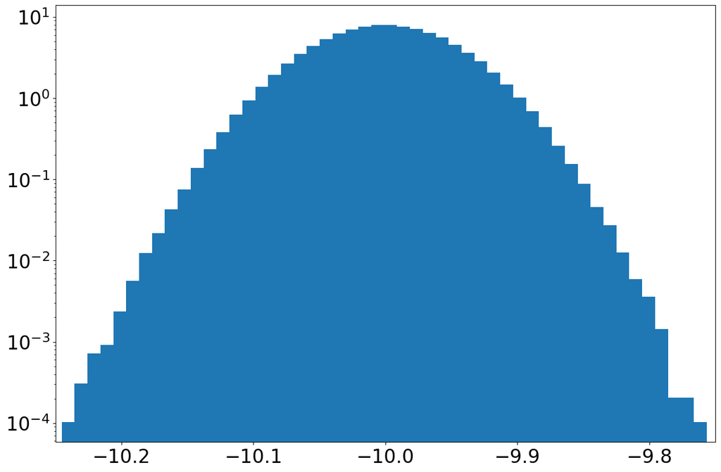

```python
ax = plt.hist(my_d, 50, density=True)
plt.yscale('log')
plt.tick_params(labelsize = 24)
plt.xlim([-10.25, -9.75])
plt.show()
```

- plt.yscale('log')
  - Sets y-axis's scale to a log scale
  - plt.yscale(value)

Plots the data on log scale for the y-axis. Taking the log is good for telling if the data follows a Gaussian distribution as, if it does, it will have a parabolic shape. That is the case here.

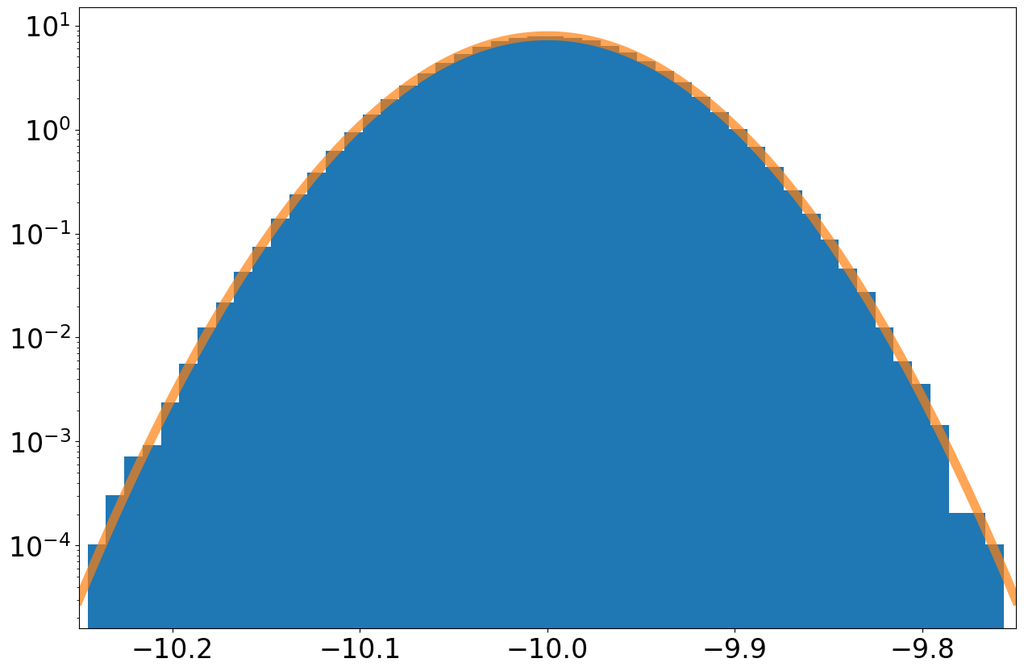

```python
fig, ax = plt.subplots(1, 1)
ax.hist(my_d, 50, density = True)
plt.yscale('log')
plt.tick_params(labelsize = 24)
plt.xlim([-10.25, -9.75])
x = np.linspace(-10.25, -9.75, 1000)
ax.plot(x, stats.norm.pdf(x, loc = -10.0, scale = 0.05), linewidth = 8, alpha = 0.7)
plt.show()
```

- The code line work the same as above

This whole code chunk plots the gaussian sample (my_d) which has a central value of -10.0 and standard deviation 0.05 as a probability density histogram with the gaussian curve pdf (ax.plot...) centered at -10.0 with a standard deviation of 0.05 on a plot with the y-axis in log scale.